# Difference-in-Differences (DiD): An Introductory Tutorial

Ohi Islam

Spring 2026

#Introduction

When introducing the difference-in-differences (DiD) method in Economics of Education, it is often helpful to begin with intuition before turning to regression. This tutorial follows a step-by-step approach. We first examine outcomes visually, then organize them in a simple table, and finally connect that setup to a regression model. The goal is to help students understand how the DiD estimate captures the additional change in outcomes for the treated group relative to the control group.

##A Simple Example

Suppose we are studying the effect of an education policy introduced for one group of schools but not another. We observe average outcomes for treatment and control groups before and after the policy.

```r
did_data <- tibble(
  group = c("Control", "Control", "Treatment", "Treatment"),
  period = c("Pre", "Post", "Pre", "Post"),
  mean_outcome = c(50, 54, 52, 62)
)

did_data
```

```
## # A tibble: 4 × 3
##   group     period mean_outcome
##   <chr>     <chr>         <dbl>
## 1 Control   Pre              50
## 2 Control   Post             54
## 3 Treatment Pre              52
## 4 Treatment Post             62
```

###Step 1: Visual Intuition

We begin with a simple graph showing average outcomes by group and period.

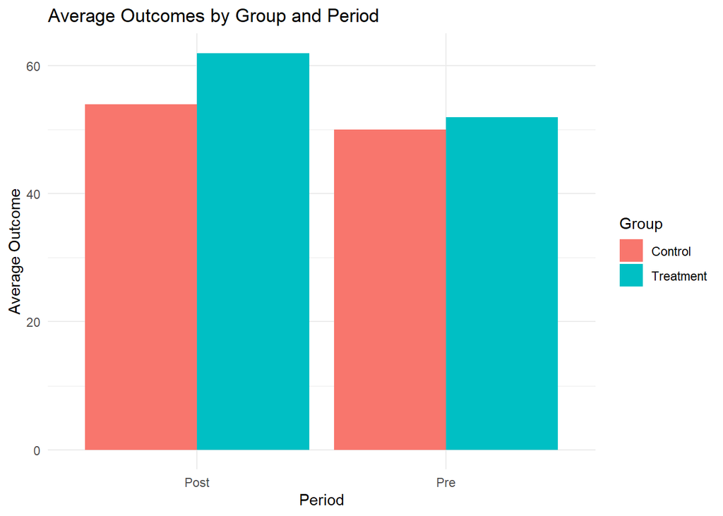

```r
ggplot(did_data, aes(x = period, y = mean_outcome, fill = group)) +
  geom_col(position = "dodge") +
  labs(
    title = "Average Outcomes by Group and Period",
    x = "Period",
    y = "Average Outcome",
    fill = "Group"
  ) +
  theme_minimal()
```

The graph allows us to compare changes over time for the treatment and control groups. The control group improves somewhat between the pre-treatment and post-treatment periods, while the treatment group improves by more. The key question is whether the additional improvement in the treatment group can be attributed to the policy.

###Step 2: Construct the DiD Table

####A useful next step is to organize the same information into a simple 2 × 2 table.

```r
did_table <- did_data %>%
  select(group, period, mean_outcome) %>%
  pivot_wider(names_from = period, values_from = mean_outcome)

did_table
```

```
## # A tibble: 2 × 3
##   group       Pre  Post
##   <chr>     <dbl> <dbl>
## 1 Control      50    54
## 2 Treatment    52    62
```

Now compute the change over time within each group.

```r
did_table <- did_table %>%
  mutate(change = Post - Pre)

did_table
```

```
## # A tibble: 2 × 4
##   group       Pre  Post change
##   <chr>     <dbl> <dbl>  <dbl>
## 1 Control      50    54      4
## 2 Treatment    52    62     10
```

The control group change is:

```r
control_change <- did_table %>% filter(group == "Control") %>% pull(change)
control_change
```

```
## [1] 4
```

The treatment group change is:

```r
treatment_change <- did_table %>% filter(group == "Treatment") %>% pull(change)
treatment_change
```

```
## [1] 10
```

The difference-in-differences estimate is:

```r
did_estimate <- treatment_change - control_change
did_estimate
```

```
## [1] 6
```

####Interpreting the DiD Estimate

The DiD estimate is:

(Treatment Post−Treatment Pre)−(Control Post−Control Pre)

Using our numbers:

(62−52)−(54−50)=10−4=6

This means the treated group experienced an increase in the outcome that was 6 units larger than the increase experienced by the control group.

###Step 3: Move from the Table to a Regression Framework

We now simulate individual-level data so we can estimate the same idea using regression.

```r
set.seed(123)

n <- 100

sim_data <- tibble(
  group = rep(c("Control", "Treatment"), each = 2 * n),
  period = rep(rep(c("Pre", "Post"), each = n), 2)
) %>%
  mutate(
    treat = if_else(group == "Treatment", 1, 0),
    post = if_else(period == "Post", 1, 0),
    treat_post = treat * post
  )
```

Now generate an outcome variable. In this example:

the baseline outcome for the control group in the pre period is 50

the treatment group starts 2 points higher

the post period increases outcomes by 4 points for everyone

the treatment group receives an additional treatment effect of 6 points in the post period

```r
sim_data <- sim_data %>%
  mutate(
    y = 50 + 2 * treat + 4 * post + 6 * treat_post + rnorm(n(), mean = 0, sd = 2)
  )

head(sim_data)
```

```
## # A tibble: 6 × 6
##   group   period treat  post treat_post     y
##   <chr>   <chr>  <dbl> <dbl>      <dbl> <dbl>
## 1 Control Pre        0     0          0  48.9
## 2 Control Pre        0     0          0  49.5
## 3 Control Pre        0     0          0  53.1
## 4 Control Pre        0     0          0  50.1
## 5 Control Pre        0     0          0  50.3
## 6 Control Pre        0     0          0  53.4
```

Check Group Means in the Simulated Data

```r
sim_means <- sim_data %>%
  group_by(group, period) %>%
  summarise(mean_y = mean(y), .groups = "drop")

sim_means
```

```
## # A tibble: 4 × 3
##   group     period mean_y
##   <chr>     <chr>   <dbl>
## 1 Control   Post     53.8
## 2 Control   Pre      50.2
## 3 Treatment Post     61.9
## 4 Treatment Pre      52.2
```

Visualize the simulated averages.

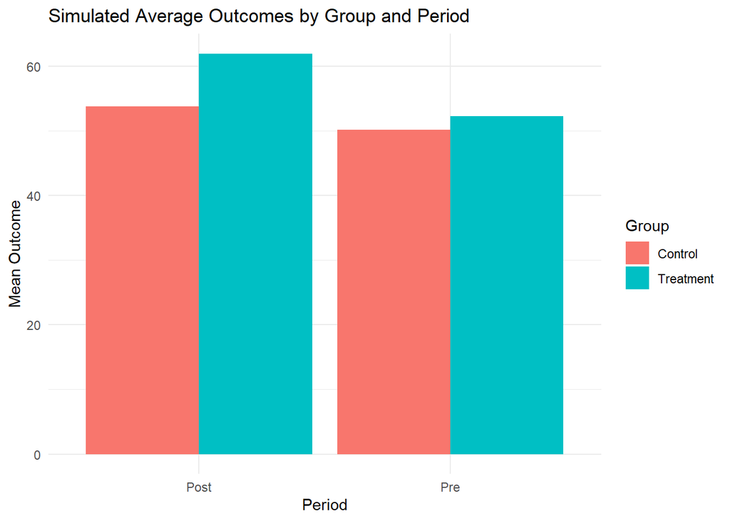

```r
ggplot(sim_means, aes(x = period, y = mean_y, fill = group)) +
  geom_col(position = "dodge") +
  labs(
    title = "Simulated Average Outcomes by Group and Period",
    x = "Period",
    y = "Mean Outcome",
    fill = "Group"
  ) +
  theme_minimal()
```

###Step 4: Estimate the DiD Regression

We now estimate the standard DiD regression:

```r
did_model <- lm(y ~ treat + post + treat_post, data = sim_data)
summary(did_model)
```

```
##
## Call:
## lm(formula = y ~ treat + post + treat_post, data = sim_data)
##
## Residuals:
##     Min      1Q  Median      3Q     Max
## -4.8594 -1.3150 -0.0997  1.3390  6.6972
##
## Coefficients:
##             Estimate Std. Error t value Pr(>|t|)
## (Intercept)  50.1808     0.1936 259.145  < 2e-16 ***
## treat         2.0601     0.2738   7.523 3.63e-13 ***
## post          3.6041     0.2738  13.161  < 2e-16 ***
## treat_post    6.0825     0.3873  15.706  < 2e-16 ***
## ---
## Signif. codes:  0 '***' 0.001 '**' 0.01 '*' 0.05 '.' 0.1 ' ' 1
##
## Residual standard error: 1.936 on 396 degrees of freedom
## Multiple R-squared:  0.8425, Adjusted R-squared:  0.8413
## F-statistic: 706.2 on 3 and 396 DF,  p-value: < 2.2e-16
```

Interpreting the Regression Coefficients

This interaction term is the main coefficient of interest.

####Linking the Graph, Table, and Regression

The graphical approach helps students see that the treatment effect is about comparing changes over time across groups. The table makes the arithmetic explicit. The regression model expresses the same logic in a compact and general form.

One useful way to think about the treatment effect is as a shift in the regression intercept for the treated group in the post-treatment period. That shift is captured by the interaction term. In this way, the regression framework formalizes the same comparison students first saw in the graph and the table.

####Why This Approach Helps

This sequence is especially useful when students have limited prior exposure to regression methods. Starting with visual and tabular intuition makes the logic of causal inference more accessible. Once students understand the comparisons in the graph and table, they are better prepared to interpret the regression coefficients and connect the model to empirical research in education policy.

#Conclusion

Difference-in-differences is a powerful method because it compares how outcomes change over time for a treated group relative to a control group. By moving from graph to table to regression, students can build intuition first and then see how that intuition is represented econometrically.